# **Topic Modelling in PyMC: *Latent Dirichlet Allocation (LDA)***

# PROBABILISTIC PROGRAMMING - PROJECT 1

### Sotir Anca-Nicoleta (AI, group 407)

#### *December 2020*

## **Setup**

```python
%%capture
!pip install pymc
!pip install unidecode
!pip install word2number
```

```python
%%capture
import pymc as pm
import numpy as np
import random
import os
from statistics import mean
import math
import copy

# text preprocessing
import string
import unidecode
import nltk
nltk.download('stopwords', quiet = True)
from nltk.corpus import stopwords
import spacy
import en_core_web_sm
nlp = en_core_web_sm.load()
from word2number import w2n
import re

# visualization
from wordcloud import WordCloud
import matplotlib.pyplot as plt
import textwrap
import seaborn as sns; sns.set_theme()
```

```python
from google.colab import drive
drive.mount('/content/drive/')
```

## **Fetching data**

The documents are stored in a file system having the following structure:

```
documents
|
|_ _ topic1
|     |_ _ doc1.txt
|     |_ _ doc2.txt
|     |_ _ ...
|
|_ _ topic2
|     |_ _ doc1.txt
|     |_ _ doc2.txt
|     |_ _ ...
|
|_ _ ...
```

```python
def print_doc(doc):
  '''
  Display a text on multiple lines, wrapped at maximum 140 chars per line.
  '''
  doc = textwrap.wrap(doc, 140)
  for line in doc:
    print(line)
```

```python
def fetch_data(data_loc = '/content/drive/MyDrive/PP_proj1/data'):
  '''
  Retrieves the number of topics and documents found at the location and a list
  containing the text content of those documents.
  '''
  raw_docs = []
  for root, dirs, files in os.walk(data_loc):
    if root == data_loc: # topic directories are located only at root
      topics_no = len(dirs)
      continue
    if '.ipynb_checkpoints' in root: # ignore notebook checkpoints
      continue
    for file in files: # read each file and add its content to raw_docs array
      with open(os.path.join(root,file), encoding='utf-8') as doc:
        raw_docs.append(doc.read())
  docs_no = len(raw_docs)
  print(f'Found {topics_no} topics and {docs_no} documents.\n')
  try:
    print('-----------------------------------------------------------------------------------------------------------------')
    print_doc('This dataset is formed by extracting text from different Wikipedia articles. Each document is 2-3 sentences long.')
    print()
    with open(os.path.join(data_loc,'document_sources.txt')) as sources:
      print(sources.read())
    print('-----------------------------------------------------------------------------------------------------------------')


  except:
    pass
  return topics_no, docs_no, raw_docs


topics_no, docs_no, raw_docs = fetch_data()
print('\nA random data sample:')
print_doc(raw_docs[random.randint(0, docs_no-1)])
```

```
Found 5 topics and 25 documents.

-----------------------------------------------------------------------------------------------------------------
This dataset is formed by extracting text from different Wikipedia articles. Each document is 2-3 sentences long.

TOPIC 1: ASTRONOMY
1: https://en.wikipedia.org/wiki/Solar_System
2: https://en.wikipedia.org/wiki/Super-Earth
3: https://en.wikipedia.org/wiki/Cosmology
4: https://en.wikipedia.org/wiki/Supernova_remnant
5: https://en.wikipedia.org/wiki/Star


TOPIC 2: BUSINESS
1: https://en.wikipedia.org/wiki/Business
2: https://en.wikipedia.org/wiki/Stock_market
3: https://en.wikipedia.org/wiki/Corporation
4: https://en.wikipedia.org/wiki/Wall_Street
5: https://en.wikipedia.org/wiki/NASDAQ


TOPIC 3: COOKING
1: https://en.wikipedia.org/wiki/Food_presentation
2: https://en.wikipedia.org/wiki/Entr%C3%A9e
3: https://en.wikipedia.org/wiki/Condiment
4: https://en.wikipedia.org/wiki/Vegetarianism
5: https://en.wikipedia.org/wiki/Culinary_arts


TOPIC 4: HISTORY
1: https://en.wikipedia.org/wiki/World_War_II
2: https://en.wikipedia.org/wiki/Soviet%E2%80%93Japanese_border_conflicts
3: https://en.wikipedia.org/wiki/German_Revolution_of_1918%E2%80%931919
4: https://en.wikipedia.org/wiki/Spanish_Civil_War
5: https://en.wikipedia.org/wiki/Second_Sino-Japanese_War


TOPIC 5: SPORTS
1: https://en.wikipedia.org/wiki/Tennis
2: https://en.wikipedia.org/wiki/Golf
3: https://en.wikipedia.org/wiki/Baseball
4: https://en.wikipedia.org/wiki/Handball
5: https://en.wikipedia.org/wiki/Volleyball

-----------------------------------------------------------------------------------------------------------------

A random data sample:
The Spanish Civil War exposed political divisions across Europe. The right and the Catholics supported the Nationalists to stop the spread
of Bolshevism. On the left, including labour unions, students and intellectuals, the war represented a necessary battle to stop the spread
of fascism.
```

## **Text preprocessing**

**To preprocess the text I have chosen the following approach:**

- lowercasing all text
- replacing special characters such as accents (transforming *entrée* to *entree*)
- tokenization
- removing punctuation
- removing stopwords (english text only)

```python
stop_words = stopwords.words('english') # these are words with no semantic impact on the sentence
stop_words.append('s') # also consider 's' as stopword
```

```python
def preprocess(text):
  '''
  The result is a list of tokens obtained by preprocessing the provided text.
  '''
  text = unidecode.unidecode(text).lower() # remove special characters and lowercase all text
  doc = nlp(text) # tokenize
  doc = [word.lemma_ if word.lemma_ != "-PRON-" else word for word in doc]

  translation_table = str.maketrans('', '', string.punctuation + ' ')
  spaces = re.compile(r'^\s*$')

  ans = [str(word).translate(translation_table) for word in doc] # remove punctuation
  ans = [word for word in ans if not str(word) == '']            # eliminate remaining empty terms
  ans = [word for word in ans if not spaces.match(str(word))]    # eliminate remaining spaces
  ans = [word for word in ans if not str(word) in stop_words]    # remove stopwords

  return ans


random_text_sample = raw_docs[random.randint(0, docs_no-1)]
print('An example of preprocessing:\n')
print('Raw text:')
print_doc(random_text_sample)
print('\nResult:')
print_doc(str(preprocess(random_text_sample)))
```

```
An example of preprocessing:

Raw text:
The German Revolution or November Revolution was a civil conflict in the German Empire at the end of the First World War that resulted in
the replacement of the German federal constitutional monarchy with a democratic parliamentary republic that later became known as the Weimar
Republic.

Result:
['german', 'revolution', 'november', 'revolution', 'civil', 'conflict', 'german', 'empire', 'end', 'first', 'world', 'war', 'result',
'replacement', 'german', 'federal', 'constitutional', 'monarchy', 'democratic', 'parliamentary', 'republic', 'later', 'become', 'know',
'weimar', 'republic']
```

```python
# preprocess all raw documents
docs = [preprocess(raw_doc) for raw_doc in raw_docs] # this data can be used for the model
```

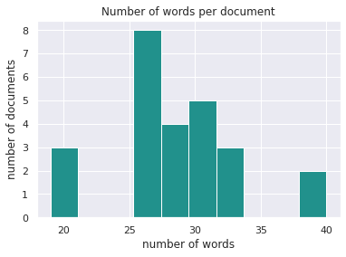

```
Average number of words per document: 28.52
```

```python
# print the average number of words per document
doc_lengths = [len(doc) for doc in docs]
plt.hist(doc_lengths, color = plt.get_cmap("viridis")(0.5));
plt.xlabel('number of words')
plt.ylabel('number of documents')
plt.title('Number of words per document')
plt.show()
print(f'Average number of words per document: {mean(doc_lengths)}')
```

## **PyMC Modelling**

I have implemented a class that encapsulates the following concepts and functionalities:

- the model's architecture (hyperparameters and variables)
- fitting the model using Markov chain Monte Carlo
- visualization of the last trace
- other visualizations based on the last trace
  - topic visualization using both term probability distribution and term score presented in **[1]** (top words)
  - document visualization using both the topic distribution and the words' topic assignment
  - topic-based similarity between documents based on both Hellinger distance **[1]** and Jensen-Shannon distance **[2]** (distance matrix and most similar documents)
  - adding a new document to the model and assigning topics to it (by restarting the inference from scratch or by continuing the inference from the last trace)

[1] [Blei, Lafferty, 2009](http://www.cs.columbia.edu/~blei/papers/BleiLafferty2009.pdf)

[2] [Shao, Qin, 2014](https://www.google.com/url?sa=t&rct=j&q=&esrc=s&source=web&cd=&ved=2ahUKEwi4guDJiNTtAhUvzoUKHW_TDlsQFjAAegQIAxAC&url=https%3A%2F%2Fwww.atlantis-press.com%2Farticle%2F13639.pdf&usg=AOvVaw050lI-k9xP5YUEzv9Lxz3_)

```python
class LDA_model():
  '''
  Latent Dirichlet Allocation (LDA) in PyMC
  '''
  def __init__(self, topics_no = topics_no, docs = docs):
    '''
    Given a number of topics and some documents, create the hidden structure of the model and
    prepare it for the MCMC sampling procedure.
    '''
    self.docs = docs
    self.K = topics_no
    self.M = len(docs)
    # create a dictionary containing (word: index) pairs
    self.build_vocab()
    self.N = len(self.vocab_idx)
    self.Nw = [len(doc) for doc in self.docs]
    # set the concentration parameter for the Dirichlet distributions to 1
    self.alpha = np.full(self.K, 1)
    self.beta = np.full(self.N, 1)
    # create the variables of the model
    self.create_theta()
    self.create_phi()
    self.create_z()
    self.create_w()


  def build_vocab(self):
    '''
    Creating a dictionary such that all words from all documents have a unique index assigned.
    Also creates a list of documents where the words are replaced by the index.
    '''
    self.vocab_idx = {}
    for doc in self.docs:
      for word in doc:
        if not word in self.vocab_idx: # add the current word to the dict only if it doesn't exist already in the vocabulary
          self.vocab_idx[word] = len(self.vocab_idx)
    self.docs_idx = [[self.vocab_idx[word] for word in doc] for doc in self.docs] # docs with index instead of words


  def get_word_by_index(self, idx):
    '''
    Returns a word from the vocabulary corresponding to the given index.
    '''
    word_list = list(self.vocab_idx.keys()) # list of words in the vocabulary
    idx_list = list(self.vocab_idx.values()) # list of indexes in the vocabulary
    return word_list[idx_list.index(idx)] # return the word corresponding to the position of idx in idx_list


  def print_info(self):
    '''
    Show the current model's number of topics, number of documents, vocabulary size and document lengths.
    '''
    print('LDA model instance\n===================')
    print(f'Number of topics:\t\tK  = {self.K}')
    print(f'Number of documents:\t\tM  = {self.M}')
    print(f'Vocabulary size:\t\tN  = {self.N}')
    print(f'Number of words per document:\tNw = {self.Nw}')


  def create_theta(self):
    '''
    Create the variable that signifies the topic mixture of each document - in other words,
    the topic distribution for each document (M K-sized Dirichlet distributions of parameter alpha).
    '''
    self.incomplete_theta = np.empty(self.M, dtype=object) # define a container for the Dirichlet variables
    self.theta = np.empty(self.M, dtype=object) # define a container for the completed Dirichlet variables
    for m in range(self.M):
      self.incomplete_theta[m] = pm.Dirichlet('incomplete_theta_'+str(m), self.alpha) # gives K-1 values (alpha is of size K)
      self.theta[m] = pm.CompletedDirichlet('theta_'+str(m), self.incomplete_theta[m]) # completes to K values (last one is 1 minus sum of others)


  def create_phi(self):
    '''
    Create the variable that signifies the topics' distribution over all words from the vocabulary
    (K N-sized Dirichlet distribution of parameter beta).
    '''
    self.incomplete_phi = np.empty(self.K, dtype=object) # define a container for the Dirichlet variables
    self.phi = np.empty(self.K, dtype=object) # define a container for the completed Dirichlet variables
    for k in range(self.K):
      self.incomplete_phi[k] = pm.Dirichlet('incomplete_phi_'+str(k), self.beta) # gives N-1 values (beta is of size N)
      self.phi[k] = pm.CompletedDirichlet('phi_'+str(k), self.incomplete_phi[k]) # completes to N values (last one is 1 minus sum of others)


  def create_z(self):
    '''
    For each word in each document, what is the probability of that word to be drawn from a given topic.
    '''
    self.z = np.empty(self.M, dtype=object) # define a container for each document
    for m in range(self.M):
      self.z[m] = np.empty(self.Nw[m], dtype=object) # define a container for each word
      for n in range(self.Nw[m]):
        self.z[m][n] = pm.Multinomial('z_'+str(m)+'_'+str(n), 1, self.theta[m]) # with respect to theta, the topic mixture of the document
                                                                                # draw only one topic for that respective word in the document


  def create_w(self):
    '''
    Create the observed variables, given by the documents themselves. Words have been drawn with respect to the topic mixture of
    the most probable topic for that word in the context of the document.
    '''
    self.w = np.empty(self.M, dtype=object) # define a container for each document
    for m in range(self.M):
      self.w[m] = np.empty(self.Nw[m], dtype=object) # define a container for each word
      for n in range(self.Nw[m]):                 # the multinomial result is given by an array with all 0 and only one 1
        observed_value = np.zeros(self.N)         # the position of the 1 in the array gives the classification (the word index)
        observed_value[self.docs_idx[m][n]] = 1   # the observations was provided through the value parameter, and observed is set to True
        self.w[m][n] = pm.Multinomial('w_'+str(m)+'_'+str(n), 1, self.phi[np.argmax(self.z[m][n])], value=observed_value, observed=True)
                                          # phi(argmax(z[m][n])) gives the distribution of the most probable topic for word n in document m


  def fit_and_trace(self, iter = 10000, burn = 5000, step = 1):
    '''
    Define the Model with the created variables and observations.
    Use MCMC to make samples from the a-posteriori distributions of theta, phi and z.
    Save the last trace for the visualizations to follow.
    '''
    # also provide incomplete Dirichlet because they are the parent variables of the completed Dirichlet
    self.model = pm.Model([self.incomplete_theta, self.incomplete_phi, self.theta, self.phi, self.z, self.w])
    self.mcmc = pm.MCMC(self.model)
    self.mcmc.sample(iter, burn, step)

    # extract the last sample for the variables using trace
    self.incomplete_phi_sample = []
    for k in range(self.K):
      self.incomplete_phi_sample.append(self.mcmc.trace('incomplete_phi_'+str(k))[-1])
```

```python
    self.incomplete_theta_sample = []
    for m in range(self.M):
      self.incomplete_theta_sample.append(self.mcmc.trace('incomplete_theta_'+str(m))[-1])

    self.phi_sample = []
    for k in range(self.K):
      self.phi_sample.append(self.mcmc.trace('phi_'+str(k))[-1])

    self.theta_sample = []
    for m in range(self.M):
      self.theta_sample.append(self.mcmc.trace('theta_'+str(m))[-1])

    self.z_sample = []
    for m in range(self.M):
      z_m = []
      for n in range(self.Nw[m]):
        z_m.append(self.mcmc.trace('z_'+str(m)+'_'+str(n))[-1])
      self.z_sample.append(z_m)


  def print_last_trace(self):
    '''
    Show the last iteration of the MCMC sampling for variables theta, phi and z.
    '''
    print('\nLast MCMC iteration\n===============================================')
    print('Document distributions over topics:\n')
    for m in range(self.M):
      print(self.theta_sample[m])
    print('\n-----------------------------------------------')
    print('Topic distributions over vocabulary:\n')
    for k in range(self.K):
      print(self.phi_sample[k])
    print('\n-----------------------------------------------')
    print('Topic of each word for each document:\n')
    for m in range(self.M):
      print(f'Document {m}: {self.docs[m]}')
      for n in range(self.Nw[m]):
        print(str(np.argmax(self.z_sample[m][n])), end = ' ')
      print('\n')


  def term_score(self, k, w):
    '''
    Instead of relying only on the term probability under a given topic (phi[k]),
    this method also down-weights terms with high probability under all topics.
    '''
    beta = [self.phi_sample[k].flatten()[w] + 0.01 for k in range(self.K)] # also apply smoothing for log-computations
    sum_of_logs = 0
    for j in range(self.K):
      sum_of_logs += math.log(beta[j])
    score = beta[k] * (math.log(beta[k]) - 1/self.K * sum_of_logs)
    return score


  def visualize_topics(self, method, top_words_percent = 0.05):
    '''
    A topic can be visualized by arranging the terms in descending order of either term probability or term score.
    Top words are displayed in both bar chart and word cloud forms.
    '''
    top_words_no = round(top_words_percent * self.N) # top 5% of the vocabulary is considered

    if method == 'term-probability': # terms are ordered by probability values given by phi
      probabilities = [self.phi_sample[k].flatten() for k in range(self.K)]
      top_words_idx = [np.argsort(probabilities[k])[-top_words_no:] for k in range(self.K)] # 5% biggest probabilities for each topic
      top_words = [] # this array will hold actual word representation for better visualisation
      top_words_val = [] # this array will hold the probability values
      for k in range(self.K): # all topics are visualized
          top_words.append([self.get_word_by_index(idx) for idx in top_words_idx[k]]) # get actual word from vocabulary (corresponding to top index)
          top_words_val.append(np.sort(probabilities[k])[-top_words_no:]) # get biggest probabilities
    if method == 'term-score': # terms are ordered by the score computed according to Blei and Lafferty, 2009
      term_scores = []
      for k in range(self.K):
        term_scores.append([self.term_score(k, w) for w in range(self.N)]) # compute all scores
      top_words_idx = [np.argsort(term_scores[k])[-top_words_no:] for k in range(self.K)] # get term index with biggest scores
      top_words = [] # this array will hold actual word representation for better visualisation
      top_words_val = [] # this array will hold the score values
      for k in range(self.K): # all topics are visualized
          top_words.append([self.get_word_by_index(idx) for idx in top_words_idx[k]]) # get actual word from vocabulary (corresponding to top index)
          top_words_val.append(np.sort(term_scores[k])[-top_words_no:]) # get biggest scores

    # both bar chart and word cloud are generated for each topic
    fig, axs = plt.subplots(self.K, 2, figsize = (self.K * 3, self.K * 6))
    plt.subplots_adjust(hspace = 0.5)
    for k in range(self.K):
      axs[k][0].barh(top_words[k], top_words_val[k], color = plt.get_cmap("viridis")(0.5));
      axs[k][0].set_title(f'Topic {k+1}')
    for k in range(self.K):
      top = {word: prob for word, prob in zip(top_words[k], top_words_val[k])}
      wordcloud = WordCloud(width=1200, height=600, background_color = 'white', colormap = 'viridis', prefer_horizontal = True)
      wordcloud.generate_from_frequencies(frequencies = top)
      axs[k][1].imshow(wordcloud)
      axs[k][1].axis('off')
      axs[k][1].set_title(f'Top Words for Topic {k+1}')


  def visualize_document(self, doc_idx = None):
    '''
    A document can be visualized with respect to its topic mixture (theta) and to the topic assigned to its words (z).
    If no document index is provided, an index will be considered randomly.
    '''
    if doc_idx is None:
      doc_idx = random.randint(0, self.M-1)
    print(f'Document #{doc_idx}:\n')
    print_doc(raw_docs[doc_idx])
    print()

    word_topic_assignments = [np.argmax(self.z_sample[doc_idx][n]) for n in range(self.Nw[doc_idx])] # get most probable topic for each word
    word_topics = [[] for k in range(self.K)] # for each topic the actual vocabulary words that are assigned to it are shown
    for i in range(self.Nw[doc_idx]):
      current_word = self.get_word_by_index(self.docs_idx[doc_idx][i])
      word_topics[word_topic_assignments[i]].append(current_word) # place the vocabulary word into the assigned topic list

    print('Topic assignments for the words in this document:')
    print('-------------------------------------------------')
    for k in range(self.K):
      print(f'Topic {k+1}: {", ".join(word_topics[k])}')
    print()

    fig, axs = plt.subplots(1, 2, figsize = (15,5))
    plt.subplots_adjust(wspace = 0.5)
    # first plot is with respect to the topic mixture of the document
    axs[0].bar(['topic ' + str(k+1) for k in range(self.K)], self.theta_sample[doc_idx][-1].flatten(), color = plt.get_cmap("viridis")(0.5))
    axs[0].set_title(f'Topic mixture of document #{doc_idx}')
    axs[0].set_ylabel('percentage')
    # second plot is with respect to the topic assigned to the words in the document
    axs[1].bar(['topic ' + str(k+1) for k in range(self.K)], np.bincount(word_topic_assignments, minlength = self.K), color = plt.get_cmap("viridis")(0.25))
    axs[1].set_title(f'Topic assignments for the words from document #{doc_idx}')
    axs[1].set_ylabel('number of words assigned to the topic')
```

```python
  def cosine_similarity(self, doc1, doc2):
    '''
    Computes the cosine similarity between the two vectors given by the topic mixtures.
    '''
    a = self.theta_sample[doc1].flatten()
    b = self.theta_sample[doc2].flatten()
    similarity = np.dot(a, b) / (math.sqrt(np.dot(a, a)) * math.sqrt(np.dot(b, b)))
    return similarity


  def hellinger_distance(self, doc1, doc2):
    '''
    Topic-based similarity between doc1 and doc2 is given by their Hellinger distance,
    computed according to Blei and Lafferty, 2009.
    '''
    hellinger_dist = 0
    for k in range(self.K):
      hellinger_dist += (math.sqrt(self.theta_sample[doc1].flatten()[k]) - math.sqrt(self.theta_sample[doc2].flatten()[k]))**2
    return hellinger_dist


  def kl_distance(self, p, q):
    '''
    Used to compute the Jensen-Shannon distance between two documents.
    Distance between two probability distributions p and q.
    '''
    T = len(p)
    kl_dist = 0
    for i in range(T):
      kl_dist += p[i] * (math.log(p[i]) - math.log(q[i]))
    return kl_dist


  def js_distance(self, doc1, doc2):
    '''
    Topic-based similarity between doc1 and doc2 is given by their Jensen-Shannon distance,
    computed according to Shao and Qin, 2014.
    '''
    p = self.theta_sample[doc1].flatten()
    q = self.theta_sample[doc2].flatten()
    p_q_avg = [(p[i] + q[i]) / 2 for i in range(self.K)]
    js_dist = 1/2 * (self.kl_distance(p, p_q_avg) + self.kl_distance(q, p_q_avg))
    return js_dist


  def docs_similarity_matrix(self):
    '''
    Calculates the cosine similarity and the distance (both Hellinger and Jensen-Shannon) between all documents and
    provides a visual representation using a similarity matrix for each method.
    '''
    self.similarity_matrix_cosine = np.zeros((self.M, self.M))    # cosine similarity
    self.similarity_matrix_hellinger = np.zeros((self.M, self.M)) # similarity given by Hellinger distance
    self.similarity_matrix_js = np.zeros((self.M, self.M))        # similarity given by Jensen-Shannon distance
    for m1 in range(self.M):
      for m2 in range(self.M):
        self.similarity_matrix_cosine[m1][m2] = self.cosine_similarity(m1, m2)
        self.similarity_matrix_hellinger[m1][m2] = self.hellinger_distance(m1, m2)
        self.similarity_matrix_js[m1][m2] = self.js_distance(m1, m2)

    # plot the cosine similarity matrix and the similarity matrix for both distances
    grid_kws = {"height_ratios": (.9, .1), "wspace": .3}
    fig, ((ax0, ax1, ax2), (cbar_ax0, cbar_ax1, cbar_ax2)) = plt.subplots(2, 3, figsize = (24,12), gridspec_kw = grid_kws)
    ax0 = sns.heatmap(self.similarity_matrix_cosine, ax = ax0, cbar_ax = cbar_ax0, cbar_kws = {'orientation': 'horizontal'}, square = True, cmap = 'viridis')
    ax0.set_yticklabels(ax0.get_yticklabels(), rotation = 0)
    ax0.set_xticklabels(ax0.get_xticklabels(), rotation = 0)
    ax0.set_title('Cosine similarity')
    ax1 = sns.heatmap(self.similarity_matrix_hellinger, ax = ax1, cbar_ax = cbar_ax1, cbar_kws = {'orientation': 'horizontal'}, square = True, cmap = 'viridis')
    ax1.set_yticklabels(ax1.get_yticklabels(), rotation = 0)
    ax1.set_xticklabels(ax1.get_xticklabels(), rotation = 0)
    ax1.set_title('Hellinger distance')
    ax2 = sns.heatmap(self.similarity_matrix_js, ax = ax2, cbar_ax = cbar_ax2, cbar_kws = {'orientation': 'horizontal'}, square = True, cmap = 'viridis')
    ax2.set_yticklabels(ax2.get_yticklabels(), rotation = 0)
    ax2.set_xticklabels(ax2.get_xticklabels(), rotation = 0)
    ax2.set_title('Jensen-Shannon distance')


  def get_similar_doc(self, doc_idx = None):
    '''
    Returns the most similar (i.e. the closest) document to the given one (both considering Hellinger and Jensen-Shannon distances).
    If no document index is provided, an index will be considered randomly.
    '''
    if doc_idx is None:
      doc_idx = random.randint(0, self.M-1)
    print(f'Given document #{doc_idx}:')
    print_doc(raw_docs[doc_idx])
    # argmax(similarity_matrix[doc]) gives the maximum cosine similarity between doc and any other document (documents must be different)
    most_similar_idx_cosine = np.argmax([self.similarity_matrix_cosine[doc_idx][i] for i in range(self.M) if not i == doc_idx])
    print(f'\nMost similar document by cosine similarity: #{most_similar_idx_cosine}')
    print_doc(raw_docs[most_similar_idx_cosine])
    # argmin(similarity_matrix[doc]) gives the minimum distance between doc and any other document (documents must be different)
    most_similar_idx_hellinger = np.argmin([self.similarity_matrix_hellinger[doc_idx][i] for i in range(self.M) if not i == doc_idx])
    print(f'\nMost similar document by Hellinger distance: #{most_similar_idx_hellinger}')
    print_doc(raw_docs[most_similar_idx_hellinger])
    most_similar_idx_js = np.argmin([self.similarity_matrix_js[doc_idx][i] for i in range(self.M) if not i == doc_idx])
    print(f'\nMost similar document by Jensen-Shannon distance: #{most_similar_idx_js}')
    print_doc(raw_docs[most_similar_idx_js])


  def add_new_document(self, doc, continue_inference = False):
    '''
    Adding a new document to the model and assigning topics to it. The two approaches are restarting the inference from scratch and
    restarting the inference from the last trace obtained previously.
    '''
    self.docs.append(doc) # adding the new document to the model's document list
    self.M += 1 # increasing the documents number
    # add any new words that may appear in the new document to the vocabulary
    for word in doc:
      if not word in self.vocab_idx:
        self.vocab_idx[word] = len(self.vocab_idx)
    # add the document with words replaced by their index to the model's list
    self.docs_idx.append([self.vocab_idx[word] for word in doc])
    # update the total number of words of the vocabulary (if it increased with the new document's appearance)
    self.N = len(self.vocab_idx)
    self.Nw.append(len(doc)) # add the new document's length to the model's list
    self.beta = np.full(self.N, 1) # the beta hyperparameter's shape is updated (vocabulary size)
    if continue_inference == False: # in the case of restarting the inference from scratch,
      self.create_theta()           # the variables can be created with random initial values
      self.create_phi()             # according to the model's generative story
      self.create_z()
      self.create_w()
    if continue_inference == True: # in the case of continuing the inference from last trace, the corresponding values must be provided to the variables
      self.incomplete_theta = np.empty(self.M, dtype=object)
      self.theta = np.empty(self.M, dtype=object)
      for m in range(self.M):
        if m < self.M-1:  # for the old documents, their apriori can be considered the last previous trace
          self.incomplete_theta[m] = pm.Dirichlet('incomplete_theta_'+str(m), self.alpha, value = self.incomplete_theta_sample[m])
        else:             # for the last document, which is the new one, no additional value is provided
          self.incomplete_theta[m] = pm.Dirichlet('incomplete_theta_'+str(m), self.alpha)
        self.theta[m] = pm.CompletedDirichlet('theta_'+str(m), self.incomplete_theta[m]) # complete the Dirichlet as usual
      oldN = len(self.phi_sample[0].flatten()) # how many words did the vocabulary have before adding the last document
      self.incomplete_phi = np.empty(self.K, dtype=object)
      self.phi = np.empty(self.K, dtype=object)
      for k in range(self.K): # for each topic, the distribution must be enlarged with some random values to fit the new vocabulary size
        new_prior = np.append(self.phi_sample[k], np.random.random(size = self.N-oldN)) # random values between 0 and 1 are added at the end
        new_prior /= np.sum(new_prior) # the sum must be 1 because it is a probability distribution so we divide by the sum of all values
        new_prior = new_prior[:-1] # we must provide this to the incomplete variable so we eliminate the last one which can be deduced
        self.incomplete_phi[k] = pm.Dirichlet('incomplete_phi_'+str(k), self.beta, value = new_prior)
        self.phi[k] = pm.CompletedDirichlet('phi_'+str(k), self.incomplete_phi[k])
      self.z = np.empty(self.M, dtype=object) # for z, similarly to theta, only the last variables corresponding to the new document
      for m in range(self.M):                 # will have a random value, and the others before it will be provided the last previous trace
        self.z[m] = np.empty(self.Nw[m], dtype=object)
        if m < self.M-1:
          for n in range(self.Nw[m]):                                               # for the variables that do not correspond to the new document
            self.z[m][n] = pm.Multinomial('z_'+str(m)+'_'+str(n), 1, self.theta[m], value = self.z_sample[m][n]) # last previous trace is provided
        else:
          for n in range(self.Nw[m]):
            self.z[m][n] = pm.Multinomial('z_'+str(m)+'_'+str(n), 1, self.theta[m]) # for the last document, no additional value is provided
      self.create_w() # observed variables are created same as before, they have a fixed observed value
```

```python
  def lda_model_copy(self):
    '''
    Returns a new model instance as a copy of the current model. This is useful to show the effects of adding a new document to a model
    and either restarting the inference from scratch as opposed to continuing the inference from last trace.
    '''
    model_copy = LDA_model(self.K, self.docs) # create a new model
    model_copy.incomplete_phi_sample = copy.deepcopy(self.incomplete_phi_sample)      # the samples are important to continue the inference
    model_copy.incomplete_theta_sample = copy.deepcopy(self.incomplete_theta_sample)  # from the last trace obtained with a model
    model_copy.phi_sample = copy.deepcopy(self.phi_sample)
    model_copy.theta_sample = copy.deepcopy(self.theta_sample)
    model_copy.z_sample = copy.deepcopy(self.z_sample)
    return model_copy
```

### **Sanity Check**

I have also included the results for the sanity check.

```python
sanity_data = [['aaa', 'bbb', 'aaa'],
               ['bbb', 'aaa', 'bbb'],
               ['aaa', 'bbb', 'bbb', 'aaa'],
               ['uuu', 'vvv'],
               ['uuu', 'vvv', 'vvv'],
               ['uuu', 'vvv', 'vvv', 'uuu']]

sanity_model = LDA_model(2, sanity_data)
sanity_model.print_info()
print()

sanity_model.fit_and_trace()
print()

sanity_model.print_last_trace()
```

```
LDA model instance
===================
Number of topics:		K  = 2
Number of documents:		M  = 6
Vocabulary size:		N  = 4
Number of words per document:	Nw = [3, 3, 4, 2, 3, 4]
```

```
 [-----------------100%-----------------] 10000 of 10000 complete in 20.3 sec

Last MCMC iteration
===============================================
Document distributions over topics:

[[0.5912518 0.4087482]]
[[0.83790319 0.16209681]]
[[0.62309985 0.37690015]]
[[0.83486294 0.16513706]]
[[0.24052643 0.75947357]]
[[0.04085169 0.95914831]]

-----------------------------------------------
Topic distributions over vocabulary:

[[0.25331911 0.24761941 0.27120302 0.22785846]]
[[0.29765854 0.43742645 0.07876635 0.18614865]]

-----------------------------------------------
Topic of each word for each document:

Document 0: ['aaa', 'bbb', 'aaa']
0 0 0

Document 1: ['bbb', 'aaa', 'bbb']
1 0 0

Document 2: ['aaa', 'bbb', 'bbb', 'aaa']
1 1 1 1

Document 3: ['uuu', 'vvv']
0 0

Document 4: ['uuu', 'vvv', 'vvv']
0 1 1

Document 5: ['uuu', 'vvv', 'vvv', 'uuu']
1 1 1 1
```

### **TASK 1: Results for the chosen dataset**

```python
# instantiating a model
lda_model = LDA_model()
lda_model.print_info()
```

```
LDA model instance
===================
Number of topics:		K  = 5
Number of documents:		M  = 25
Vocabulary size:		N  = 438
Number of words per document:	Nw = [33, 29, 27, 31, 26, 29, 32, 27, 27, 28, 27, 30, 19, 38, 31, 19, 32, 27, 40, 26, 30, 28, 26, 21, 30]
```

```python
# fitting the model
lda_model.fit_and_trace(10000, 5000)
```

```
 [-----------------100%-----------------] 10000 of 10000 complete in 516.4 sec
```

#### **Visualizing the topics**

Firstly, the topics can be visualized by **ordering the term probabilities in descending order** and reviewing the **top words** obtained in this manner.

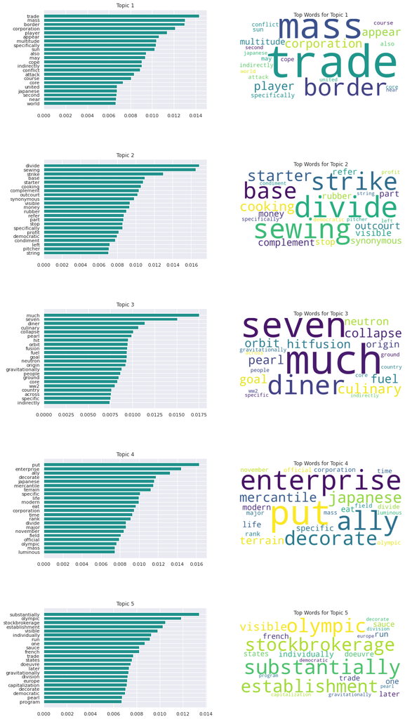

```python
# each topic is shown using a bar chart and a word cloud
lda_model.visualize_topics(method = 'term-probability')
```

Secondly, the topics can be visualized by ordering the **term scores** also in descending order and, similarly, reviewing the **top words**. This term score presented by Blei and Lafferty also ranks words with respect to the possibility that they would have a high probability under all topics.

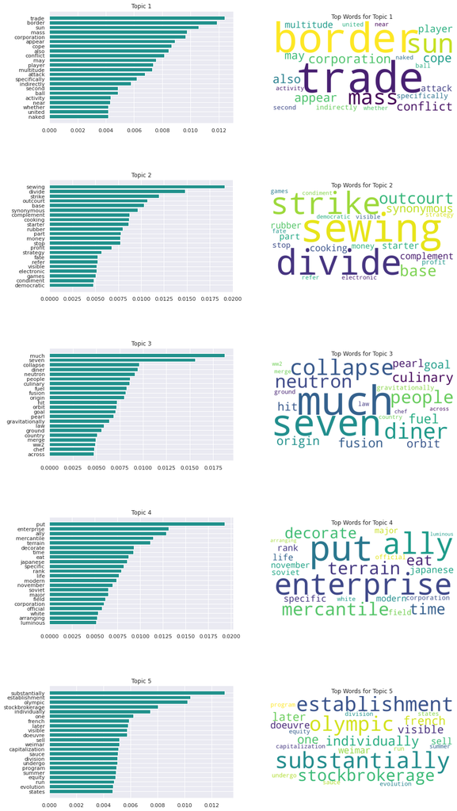

```python
lda_model.visualize_topics(method = 'term-score')
```

#### **Visualizing a document**

```
Document #12:

Cosmology is a branch of astronomy concerned with the studies of the origin and evolution of the universe, from the Big Bang to today and on
into the future. It is the scientific study of the origin, evolution, and eventual fate of the universe.

Topic assignments for the words in this document:
-------------------------------------------------
Topic 1:
Topic 2:
Topic 3: cosmology, astronomy, study, origin, evolution, universe, big, today, scientific, origin, evolution, eventual
Topic 4:
Topic 5: branch, concern, bang, future, study, fate, universe
```

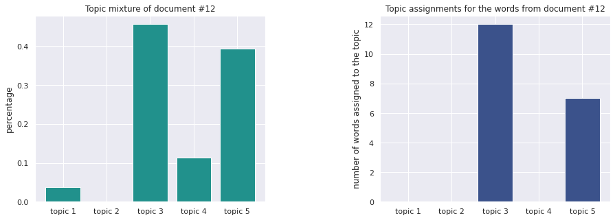

```python
lda_model.visualize_document()
```

### **TASK 2: Topic-based similarity between documents**

I have followed these approaches to compute the similarity between two documents:

- Cosine similarity (Wikipedia)
- The Hellinger distance ([Blei, Lafferty, 2009](http://www.cs.columbia.edu/~blei/papers/BleiLafferty2009.pdf))
- The Jensen-Shannon distance ([Shao, Qin, 2014](https://www.google.com/url?sa=t&rct=j&q=&esrc=s&source=web&cd=&ved=2ahUKEwi4guDJiNTtAhUvzoUKHW_TDlsQFjAAegQIAxAC&url=https%3A%2F%2Fwww.atlantis-press.com%2Farticle%2F13639.pdf&usg=AOvVaw050lI-k9xP5YUEzv9Lxz3_))

In the case of **cosine similarity**, the greater the score between two documents, the more similar they are; in opposition, for distances like **Hellinger** and **Jensen-Shannon** that are implemented here, where the greater the score, the more different the documents are. This aspect can also be seen when looking at the **similarity matrix** below.

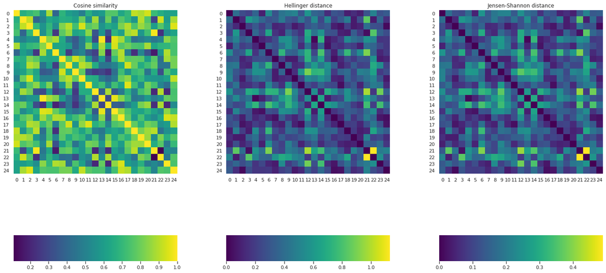

```python
lda_model.docs_similarity_matrix()
```

```python
# given a random document, the most similar document for each method is returned
lda_model.get_similar_doc()
```

```
Given document #5:
Tennis is a racket sport that can be played individually against a single opponent (singles) or between two teams of two players each
(doubles). Each player uses a tennis racket that is strung with cord to strike a hollow rubber ball covered with felt over or around a net
and into the opponent's court.

Most similar document by cosine similarity: #14
A star is an astronomical object consisting of a luminous spheroid of plasma held together by its own gravity. The nearest star to Earth is
the Sun. Many other stars are visible to the naked eye from Earth during the night, appearing as a multitude of fixed luminous points in the
sky due to their immense distance from Earth.

Most similar document by Hellinger distance: #14
A star is an astronomical object consisting of a luminous spheroid of plasma held together by its own gravity. The nearest star to Earth is
the Sun. Many other stars are visible to the naked eye from Earth during the night, appearing as a multitude of fixed luminous points in the
sky due to their immense distance from Earth.

Most similar document by Jensen-Shannon distance: #14
A star is an astronomical object consisting of a luminous spheroid of plasma held together by its own gravity. The nearest star to Earth is
the Sun. Many other stars are visible to the naked eye from Earth during the night, appearing as a multitude of fixed luminous points in the
sky due to their immense distance from Earth.
```

### **TASK 2: Assign topics to a new document**

The new document must be included in the model. For that there are two possibilities that I will approach:

1. **inference from scratch** ('reseting' the variables)
2. continuing the **inference from the last obtained trace** (the *a priori* distributions for this inference procedure are the *a posteriori* distributions obtained for the previous inference procedure).

While the first method is not difficult (it would be already solved by **creating a new model with the same number of topics and a given list of documents that also contains the new document**), the second one consists of **giving the variables the previously found distributions through the value parameter**. In that case, for variables like theta and z, the value should be given to all documents except the last one (the new document). For phi, which is affected by the possible increase in vocabulary size, the distribution must be enlarged by adding random values between 0 and 1 to the end untill reaching dimension N. Then, for phi to be a probability distribution, its elements must sum up to 1, thus we must divide the values by their collective sum. Finally, because this distribution should be given as value to an incomplete Dirichlet, the last element should be left out.

```python
new_raw_doc = '''A supernova is a powerful and luminous stellar explosion. This transient astronomical event occurs
during the last evolutionary stages of a massive star or when a white dwarf is triggered into runaway nuclear fusion.'''
raw_docs.append(new_raw_doc)
new_doc = preprocess(raw_docs[-1])

print_doc(raw_docs[-1])
print()
print_doc(str(new_doc))
```

```
A supernova is a powerful and luminous stellar explosion. This transient astronomical event occurs  during the last evolutionary stages of a
massive star or when a white dwarf is triggered into runaway nuclear fusion.

['supernova', 'powerful', 'luminous', 'stellar', 'explosion', 'transient', 'astronomical', 'event', 'occur', 'last', 'evolutionary',
'stage', 'massive', 'star', 'white', 'dwarf', 'trigger', 'runaway', 'nuclear', 'fusion']
```

```python
copy1 = lda_model.lda_model_copy()
copy2 = lda_model.lda_model_copy()
```

```python
print('INITIAL MODEL')
lda_model.print_info()
print('\nCOPY 1')
copy1.add_new_document(new_doc, continue_inference = False)
copy1.print_info()
print('\nCOPY 2')
copy2.add_new_document(new_doc, continue_inference = True)
copy2.print_info()
```

```
INITIAL MODEL
LDA model instance
===================
Number of topics:		K  = 5
Number of documents:		M  = 25
Vocabulary size:		N  = 438
Number of words per document:	Nw = [33, 29, 27, 31, 26, 29, 32, 27, 27, 28, 27, 30, 19, 38, 31, 19, 32, 27, 40, 26, 30, 28, 26, 21, 30]

COPY 1
LDA model instance
===================
Number of topics:		K  = 5
Number of documents:		M  = 26
Vocabulary size:		N  = 447
Number of words per document:	Nw = [33, 29, 27, 31, 26, 29, 32, 27, 27, 28, 27, 30, 19, 38, 31, 19, 32, 27, 40, 26, 30, 28, 26, 21, 30, 20]

COPY 2
LDA model instance
===================
Number of topics:		K  = 5
Number of documents:		M  = 26
Vocabulary size:		N  = 447
Number of words per document:	Nw = [33, 29, 27, 31, 26, 29, 32, 27, 27, 28, 27, 30, 19, 38, 31, 19, 32, 27, 40, 26, 30, 28, 26, 21, 30, 20]
```

```python
copy2.print_info()
```

```
LDA model instance
===================
Number of topics:		K  = 5
Number of documents:		M  = 26
Vocabulary size:		N  = 447
Number of words per document:	Nw = [33, 29, 27, 31, 26, 29, 32, 27, 27, 28, 27, 30, 19, 38, 31, 19, 32, 27, 40, 26, 30, 28, 26, 21, 30, 20]
```

```python
copy1.fit_and_trace(10000, 5000)
```

```
 [-----------------100%-----------------] 10001 of 10000 complete in 541.2 sec
```

```python
copy2.fit_and_trace(10000, 5000)
```

```
 [-----------------100%-----------------] 10000 of 10000 complete in 540.5 sec
```

```
INFERENCE FROM BEGINNING

Document #25:

A supernova is a powerful and luminous stellar explosion. This transient astronomical event occurs  during the last evolutionary stages of a
massive star or when a white dwarf is triggered into runaway nuclear fusion.

Topic assignments for the words in this document:
-------------------------------------------------
Topic 1: last
Topic 2: powerful, stellar, explosion, transient, evolutionary, star, white, nuclear, fusion
Topic 3: supernova, astronomical, occur, stage, massive
Topic 4: luminous
Topic 5: event, dwarf, trigger, runaway
```

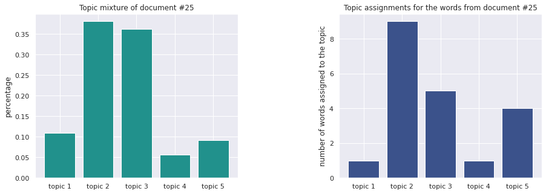

```python
print('INFERENCE FROM BEGINNING\n')
copy1.visualize_document(copy1.M-1)
```

```
INFERENCE FROM LAST TRACE

Document #25:

A supernova is a powerful and luminous stellar explosion. This transient astronomical event occurs  during the last evolutionary stages of a
massive star or when a white dwarf is triggered into runaway nuclear fusion.

Topic assignments for the words in this document:
-------------------------------------------------
Topic 1: supernova, stellar, event, last, stage, massive, trigger
Topic 2:
Topic 3:
Topic 4: powerful, luminous, transient, astronomical, evolutionary, star, white, runaway, nuclear, fusion
Topic 5: explosion, occur, dwarf
```

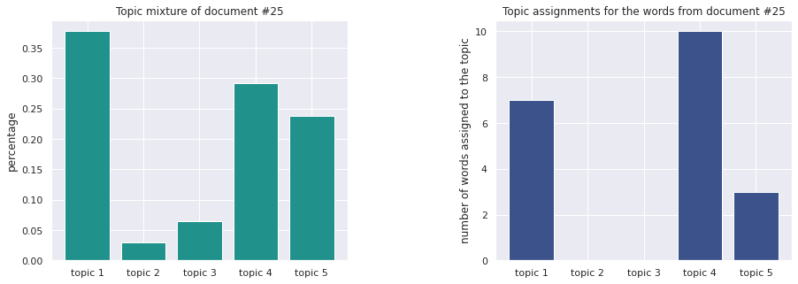

```python
print('INFERENCE FROM LAST TRACE\n')
copy2.visualize_document(copy2.M-1)
```